# Amazon Appliances' Reviews

### Extract Reviews and Metadata

### Vector DB- Pinecone

First Part (Raw data genetation - Json to Pandas):  
**Author: Atef Bader, PhD**

Second Part:(Data processing & Pinecone DB Upsertion / Quering):  
**Author: Eswarankarthik Paranthaman**

```python
import json
import ast
from pandas import DataFrame, Series
import pandas as pd
import numpy as np
import matplotlib.pyplot as plt
import seaborn as sns

from openai import OpenAI
from pinecone import Pinecone
import time
```

```python
from IPython import get_ipython

# Get the current IPython application
ip = get_ipython()

# Set the iopub_data_rate_limit
ip.kernel.config['NotebookApp']['iopub_data_rate_limit'] = 10000000
```

```python
fr=open("meta_Appliances.json")
fw=open("Amazon_Appliances_Metadata.json", "w")

for line in fr:
    json_dat = json.dumps(ast.literal_eval(line))
    dict_dat = json.loads(json_dat)
    json.dump(dict_dat, fw)
    fw.write("\n")

fw.close()
fr.close()
```

```python
fr=open("reviews_Appliances.json")
fw=open("Amazon_Appliances_Reviews.json", "w")

for line in fr:
    json_dat = json.dumps(ast.literal_eval(line))
    dict_dat = json.loads(json_dat)
    json.dump(dict_dat, fw)
    fw.write("\n")

fw.close()
fr.close()
```

```python
list_of_appliances_metadata_dict_data = [json.loads(line) for line in open('Amazon_Appliances_Metadata.json')]
```

```python
appliances_metadata_df = DataFrame(list_of_appliances_metadata_dict_data)
```

```python
appliances_metadata_df.head()
```

|  | asin | price | imUrl | description | categories | title | brand | related | salesRank |
| --- | --- | --- | --- | --- | --- | --- | --- | --- | --- |
| 0 | 0970408285 | 40.75 | http://ecx.images-amazon.com/images/I/41kQjPIF... | High-pressure hose 90 end & hose washer instal... | [[Appliances, Parts & Accessories, Washer Part... | NaN | NaN | NaN | NaN |
| 1 | 7301113188 | NaN | http://ecx.images-amazon.com/images/I/41EfFOPw... | NaN | [[Appliances, Freezers, Chest Freezers]] | NaN | NaN | NaN | NaN |
| 2 | B00002N7HY | 2.29 | http://ecx.images-amazon.com/images/I/316Y1KbT... | Built of durable thermoplastic, Leviton Power ... | [[Appliances, Parts & Accessories, Range Parts... | Leviton 5050 50 Amp, 125/250 Volt, NEMA 10-50R... | Leviton | {'also_bought': ['B000BPFZHM', 'B000VU1KC6', '... | NaN |
| 3 | B00002NATH | 9.13 | http://ecx.images-amazon.com/images/I/41srC2QF... | Built of durable thermoplastic, Leviton Power ... | [[Appliances, Parts & Accessories, Range Parts... | Leviton 7313 30 Amp, 125 Volt, NEMA Tt-30R, 2P... | Leviton | {'also_bought': ['B002OUMU66', 'B007HFT034', '... | NaN |
| 4 | B00004SQH9 | 16.29 | http://ecx.images-amazon.com/images/I/41eg0Hvy... | Coleman Cable 3536 14/3 General-Use Appliance ... | [[Appliances, Parts & Accessories, Refrigerato... | Coleman Cable 3536 14/3 General-Use Appliance ... | Coleman Cable | {'also_bought': ['B000XSNDS0', 'B0022NH420', '... | NaN |

```python
list_of_appliances_reviews_dict_data = [json.loads(line) for line in open('Amazon_Appliances_Reviews.json')]
```

```python
appliances_reviews_df = DataFrame(list_of_appliances_reviews_dict_data)
```

```python
#appliances_reviews_df.to_csv('Amazon_Appliances_Reviews.csv', encoding='utf-8', index=False)
```

```python
#appliances_metadata_df.to_csv('Amazon_Appliances_Metadata.csv', encoding='utf-8', index=False)
```

# Data Preprocessing:

```python
meta_df = appliances_metadata_df.copy()
rev_df = appliances_reviews_df.copy()
```

#### appliances_metadata_df

```python
meta_df.info()
```

```
<class 'pandas.core.frame.DataFrame'>
RangeIndex: 11656 entries, 0 to 11655
Data columns (total 9 columns):
 #   Column       Non-Null Count  Dtype
---  ------       --------------  -----
 0   asin         11656 non-null  object
 1   price        8098 non-null   float64
 2   imUrl        11647 non-null  object
 3   description  11134 non-null  object
 4   categories   11656 non-null  object
 5   title        6635 non-null   object
 6   brand        4078 non-null   object
 7   related      9070 non-null   object
 8   salesRank    2639 non-null   object
dtypes: float64(1), object(8)
memory usage: 819.7+ KB
```

##### 1.1 Data Types:

The above dataset contains 11,656 records and 9 columns. The data dictionary:

- asin: ID of the product (object)
- price: Price in US dollars (float64)
- imUrl: URL of the product image (object)
- description: Description of the product (object)
- categories: List of categories the product belongs to (object)
- title: Name of the product (object)

-brand: Brand name (object)

- related: Related products (object)
- salesRank: Sales rank information (object)

#### 1.1 Missing Value Analysis:

```python
na_counts = meta_df.isna().sum()

# Creating a DataFrame from the na_counts series
na_counts_df = pd.DataFrame(na_counts, columns=['NA_Count'])

# Reseting index to make columns accessible
na_counts_df.reset_index(inplace=True)

# Renaming columns for clarity
na_counts_df.columns = ['Column', 'NA_Count']

# Output:
na_counts_df
```

|  | Column | NA_Count |
| --- | --- | --- |
| 0 | asin | 0 |
| 1 | price | 3558 |
| 2 | imUrl | 9 |
| 3 | description | 522 |
| 4 | categories | 0 |
| 5 | title | 5021 |
| 6 | brand | 7578 |
| 7 | related | 2586 |
| 8 | salesRank | 9017 |

**Missing value Visualisation:**

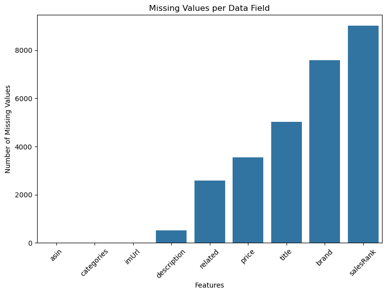

```python
na_counts_df = na_counts_df.sort_values(by=['NA_Count'],ascending= True)

# Creating bar chart:
plt.figure(figsize=(9,6))
sns.barplot(x='Column',
            y='NA_Count',
            data=na_counts_df)

plt.title('Missing Values per Data Field')
plt.xlabel('Features')
plt.ylabel('Number of Missing Values')
plt.xticks(rotation=45)
plt.show()
```

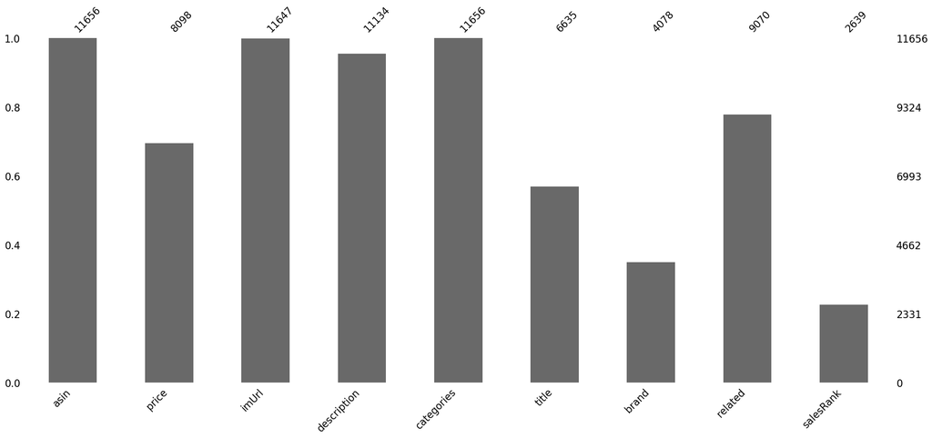

```python
import missingno as msno
msno.bar(meta_df)
```

##### 1.1 Missing Value Treatment:

**price**

There are numerous different products in this dataframe. Therefore, replacing NaN values using the mean does not make sense. Additionally, finding the local mean for each category also may not provide accurate information, as significant price variations between brands are observed. Incorporating brand information into a groupby operation similarly does not make sense, as the description reveals unique product characteristics. For example, products of the same brand and category, such as 'Gasket', can have multiple SKUs with different price ranges. Even within the category [[Appliances, Parts & Accessories, Refrigerator Parts & Accessories, Doors]], prices can range from approximately $$ 30 to $ 84.

**Droping rows of NaN: price**

```python
meta_df.dropna(subset=['price'],inplace=True)
meta_df.info()
```

```
<class 'pandas.core.frame.DataFrame'>
Index: 8098 entries, 0 to 11655
Data columns (total 9 columns):
 #   Column       Non-Null Count  Dtype
---  ------       --------------  -----
 0   asin         8098 non-null   object
 1   price        8098 non-null   float64
 2   imUrl        8098 non-null   object
 3   description  7903 non-null   object
 4   categories   8098 non-null   object
 5   title        5557 non-null   object
 6   brand        4041 non-null   object
 7   related      7373 non-null   object
 8   salesRank    1826 non-null   object
dtypes: float64(1), object(8)
memory usage: 632.7+ KB
```

**Description:**

The uniqueness of a product often lies in the 'description' feature. Therefore, missing values are not treated in 'description' column.

**Categories:**

Similarly, categories are unique to their kinds and cannot be replaced using existing information.

**title:**

```python
meta_df['title'] = meta_df['title'].fillna('unknown')
```

Title is also a unique feature and is not aggregated or generalized. However, missing values are replaced with the term 'unknown' for consistency and completeness in future analyses.

**brand:**

```python
meta_df['brand'] = meta_df['brand'].fillna('unknown', inplace=True)
```

**related & Sales Rank:**

**salesRank:**

salesRank is considered unique; hence, null values are not replaced.

### 2.0 Normalization:

```python
meta_df['description'] = meta_df['description'].str.lower().str.strip()

# Lowercase and strip whitespace for title
meta_df['title'] = meta_df['title'].str.lower().str.strip()

# Lowercase and strip whitespace for brand
meta_df['brand'] = meta_df['brand'].str.lower().str.strip()

meta_df.head()
```

|  | asin | price | imUrl | description | categories | title | brand | related | salesRank |
| --- | --- | --- | --- | --- | --- | --- | --- | --- | --- |
| 0 | 0970408285 | 40.75 | http://ecx.images-amazon.com/images/I/41kQjPIF... | high-pressure hose 90 end & hose washer instal... | [[Appliances, Parts & Accessories, Washer Part... | unknown | None | NaN | NaN |
| 2 | B00002N7HY | 2.29 | http://ecx.images-amazon.com/images/I/316Y1KbT... | built of durable thermoplastic, leviton power ... | [[Appliances, Parts & Accessories, Range Parts... | leviton 5050 50 amp, 125/250 volt, nema 10-50r... | None | {'also_bought': ['B000BPFZHM', 'B000VU1KC6', '... | NaN |
| 3 | B00002NATH | 9.13 | http://ecx.images-amazon.com/images/I/41srC2QF... | built of durable thermoplastic, leviton power ... | [[Appliances, Parts & Accessories, Range Parts... | leviton 7313 30 amp, 125 volt, nema tt-30r, 2p... | None | {'also_bought': ['B002OUMU66', 'B007HFT034', '... | NaN |
| 4 | B00004SQH9 | 16.29 | http://ecx.images-amazon.com/images/I/41eg0Hvy... | coleman cable 3536 14/3 general-use appliance ... | [[Appliances, Parts & Accessories, Refrigerato... | coleman cable 3536 14/3 general-use appliance ... | None | {'also_bought': ['B000XSNDS0', 'B0022NH420', '... | NaN |
| 5 | B00004SQH5 | 7.38 | http://ecx.images-amazon.com/images/I/31kSM%2B... | coleman cable 3531 14/3 general-use appliance ... | [[Appliances, Parts & Accessories, Refrigerato... | coleman cable 3531 14/3 general-use appliance ... | None | {'also_bought': ['B00166GQI2', 'B000KKLMKW', '... | NaN |

```python
meta_df['price'] = meta_df['price'].fillna(0.0)
meta_df['imUrl'] = meta_df['imUrl'].fillna('no image URL')
meta_df['description'] = meta_df['description'].fillna('no description available')
meta_df['categories'] = meta_df['categories'].fillna('no categories available')
meta_df['title'] = meta_df['title'].fillna('no title available')
meta_df['related'] = meta_df['related'].fillna('no related products')
meta_df['salesRank'] = meta_df['salesRank'].fillna('not ranked')
meta_df['brand'] = meta_df['brand'].fillna('unknown')  # Brand has all nulls; set a default value
```

#### appliances_reviews_df

```python
rev_df.info()
```

```
<class 'pandas.core.frame.DataFrame'>
RangeIndex: 143685 entries, 0 to 143684
Data columns (total 9 columns):
 #   Column          Non-Null Count   Dtype
---  ------          --------------   -----
 0   reviewerID      143685 non-null  object
 1   asin            143685 non-null  object
 2   reviewerName    143044 non-null  object
 3   helpful         143685 non-null  object
 4   reviewText      143685 non-null  object
 5   overall         143685 non-null  float64
 6   summary         143685 non-null  object
 7   unixReviewTime  143685 non-null  int64
 8   reviewTime      143685 non-null  object
dtypes: float64(1), int64(1), object(7)
memory usage: 9.9+ MB
```

There are null values in the reviewername column. However, this will not impact our analysis since the reviewID is available. The data Dictionary:

- reviewerID: ID of the reviewer (object).
- asin: ID of the product (object).
- reviewerName: Name of the reviewer (object).
- helpful: Information about helpfulness of the review (object).
- reviewText: Text of the review (object).
- overall: Rating of the product (float64).
- summary: Summary of the review (object).
- unixReviewTime: Time of the review in Unix time (int64).
- reviewTime: Time of the review in raw format (object).

```python
print("List of duplicated 'asin':")
rev_df[rev_df['asin'].duplicated(keep=False)].head()
```

```
List of duplicated 'asin':
```

|  | reviewerID | asin | reviewerName | helpful | reviewText | overall | summary | unixReviewTime | reviewTime |
| --- | --- | --- | --- | --- | --- | --- | --- | --- | --- |
| 3 | A2J7X7ZIH2EWB1 | B00002NATH | NaN | [0, 0] | Fast shipping. Works great | 5.0 | Five Stars | 1405814400 | 07 20, 2014 |
| 4 | AJQFNOFTZ7GOX | B00002NATH | Barthbill | [1, 1] | What can I say? It is the usual Leviton high q... | 5.0 | good product at a good price. | 1277164800 | 06 22, 2010 |
| 5 | A3EIP4ZCGM0U67 | B00002NATH | Christian Fischer | [0, 0] | The Leviton was new in the box. All screws we... | 5.0 | Great Deal and Fast Shipment | 1378339200 | 09 5, 2013 |
| 6 | A18N8ND2CH5ZZB | B00002NATH | Donn Dorminey | [0, 0] | When you need one, you need one! But if you ca... | 5.0 | Save money | 1396396800 | 04 2, 2014 |
| 7 | A35U08WK3LZ58G | B00002NATH | jim wells | [0, 0] | i needed some way to plug in my camper and thi... | 5.0 | works | 1381622400 | 10 13, 2013 |

#### unixReviewTime:

reviewTime column contains review date similar to unixReviewTime which is in unix format. date conversion is applied on unixReviewTime to extraqct date and updated reviewTime. Dropped UnixReviewTIme column as similar information is displayed in the updated reviewTime feature.

```python
rev_df['reviewTime'] = pd.to_datetime(appliances_reviews_df['unixReviewTime'], unit='s').dt.strftime('%Y-%m-%d')

# Drop the unixReviewTime column
rev_df.drop(columns=['unixReviewTime'], inplace=True)


rev_df.head()
```

|  | reviewerID | asin | reviewerName | helpful | reviewText | overall | summary | reviewTime |
| --- | --- | --- | --- | --- | --- | --- | --- | --- |
| 0 | A27HOWZBUBJ8FF | 0970408285 | Steve | [0, 0] | Could have been longer though. well made and e... | 4.0 | Good fit | 2013-12-16 |
| 1 | A24HQ894NFSTF5 | 7301113188 | Maha Saqfalhait "shopaholic! ;)" | [0, 0] | I like these containers so much i have ordered... | 5.0 | I Love the Freezer storage line.. | 2009-03-13 |
| 2 | AXE83MK90ZEVZ | B00002N7HY | Strom | [0, 0] | It works, no fires, etc. Why not 5 stars? Ho... | 4.0 | expectations achieved. | 2014-01-07 |
| 3 | A2J7X7ZIH2EWB1 | B00002NATH | NaN | [0, 0] | Fast shipping. Works great | 5.0 | Five Stars | 2014-07-20 |
| 4 | AJQFNOFTZ7GOX | B00002NATH | Barthbill | [1, 1] | What can I say? It is the usual Leviton high q... | 5.0 | good product at a good price. | 2010-06-22 |

### Missing Value Treatment:

```python
rev_df['reviewerName'] = rev_df['reviewerName'].fillna('anonymous')
```

Null values in the reviewerName column have been replaced with the term 'anonymous'.

### Normalization : Text data

```python
rev_df['summary'] = rev_df['summary'].str.lower().str.strip()

# Lowercase and strip whitespace for title
rev_df['reviewText'] = rev_df['reviewText'].str.lower().str.strip()


rev_df.head()
```

|  | reviewerID | asin | reviewerName | helpful | reviewText | overall | summary | reviewTime |
| --- | --- | --- | --- | --- | --- | --- | --- | --- |
| 0 | A27HOWZBUBJ8FF | 0970408285 | Steve | [0, 0] | could have been longer though. well made and e... | 4.0 | good fit | 2013-12-16 |
| 1 | A24HQ894NFSTF5 | 7301113188 | Maha Saqfalhait "shopaholic! ;)" | [0, 0] | i like these containers so much i have ordered... | 5.0 | i love the freezer storage line.. | 2009-03-13 |
| 2 | AXE83MK90ZEVZ | B00002N7HY | Strom | [0, 0] | it works, no fires, etc. why not 5 stars? ho... | 4.0 | expectations achieved. | 2014-01-07 |
| 3 | A2J7X7ZIH2EWB1 | B00002NATH | anonymous | [0, 0] | fast shipping. works great | 5.0 | five stars | 2014-07-20 |
| 4 | AJQFNOFTZ7GOX | B00002NATH | Barthbill | [1, 1] | what can i say? it is the usual leviton high q... | 5.0 | good product at a good price. | 2010-06-22 |

```python
rev_df.info()
```

```
<class 'pandas.core.frame.DataFrame'>
RangeIndex: 143685 entries, 0 to 143684
Data columns (total 8 columns):
 #   Column        Non-Null Count   Dtype
---  ------        --------------   -----
 0   reviewerID    143685 non-null  object
 1   asin          143685 non-null  object
 2   reviewerName  143685 non-null  object
 3   helpful       143685 non-null  object
 4   reviewText    143685 non-null  object
 5   overall       143685 non-null  float64
 6   summary       143685 non-null  object
 7   reviewTime    143685 non-null  object
dtypes: float64(1), object(7)
memory usage: 8.8+ MB
```

#### Join appliances meta data frame and reviews data frame:

```python
# Left Join: Analysing available Reviews data.
rev_meta_df = pd.merge(rev_df, meta_df, on='asin', how='left')

# Left Join: Analysing available Product data.
meta_rev_df = pd.merge(meta_df,rev_df, on='asin', how='left')

merged_df = pd.merge(rev_df,meta_df, on='asin',how='inner')

merged_df.info()
```

```
<class 'pandas.core.frame.DataFrame'>
RangeIndex: 127424 entries, 0 to 127423
Data columns (total 16 columns):
 #   Column        Non-Null Count   Dtype
---  ------        --------------   -----
 0   reviewerID    127424 non-null  object
 1   asin          127424 non-null  object
 2   reviewerName  127424 non-null  object
 3   helpful       127424 non-null  object
 4   reviewText    127424 non-null  object
 5   overall       127424 non-null  float64
 6   summary       127424 non-null  object
 7   reviewTime    127424 non-null  object
 8   price         127424 non-null  float64
 9   imUrl         127424 non-null  object
 10  description   127424 non-null  object
 11  categories    127424 non-null  object
 12  title         127424 non-null  object
 13  brand         127424 non-null  object
 14  related       127424 non-null  object
 15  salesRank     127424 non-null  object
dtypes: float64(2), object(14)
memory usage: 15.6+ MB
```

#### Pinecone:

```python
from pinecone import Pinecone, ServerlessSpec
import pinecone
import openai
from openai import OpenAI
import pandas as pd
import numpy as np
```

**NORMALIZE TEXT DATA:**

```python
pd.set_option('display.max_colwidth', None)
subset = merged_df.iloc[:,[0,1,4]]
subset['reviewText'] = subset['reviewText'].apply(lambda x: str(x))
subset['asin'] = subset['asin'].apply(lambda x: str(x))
subset['reviewerID'] = subset['reviewerID'].apply(lambda x: str(x))
```

### pinecone

```python
import pandas as pd
from openai import OpenAI
from pinecone import Pinecone, ServerlessSpec

#  OpenAI client initialisation:
OPEN_AI_API_KEY = '****'
openai_client = OpenAI(api_key=OPEN_AI_API_KEY)

# Pinecone client instance initialisation:
PINECONE_API_KEY = '***'
pc = Pinecone(api_key=PINECONE_API_KEY)

# Index configuration
INDEX_NAME = 'amazon-meta-review-data1'
DIMENSION = 1536

# Index Creation:
pc.create_index(
    name=INDEX_NAME,
    dimension=DIMENSION,
    metric='euclidean',
    spec=ServerlessSpec(
        cloud='aws',
        region='us-east-1'
    )
)
index = pc.Index(INDEX_NAME)

# Vector embedding conversion:
def get_embedding(text):
    response = openai_client.embeddings.create(input=[text], engine='text-embedding-ada-002')
    return response['data'][0]['embedding']

# Preprocessing function:
def prepare_data(df):
    upsert_data = []
    for i, row in df.iterrows():
        embedding = get_embedding(row['reviewText'])
        upsert_data.append((str(i), embedding, {
            'reviewerID': row['reviewerID'],
            'asin': row['asin'],
            'reviewerName': row['reviewerName'],
            'helpful': row['helpful'],
            'overall': row['overall'],
            'summary': row['summary'],
            'reviewTime': row['reviewTime'],
            'price': row['price'],
            'imUrl': row['imUrl'],
            'description': row['description'],
            'categories': row['categories'],
            'title': row['title'],
            'brand': row['brand'],
            'related': row['related'],
            'salesRank': row['salesRank']
        }))
    return upsert_data

# Function to upsert data in batches:
def upsert_in_batches(df, batch_size=1000):
    total_rows = len(df)
    for start in range(0, total_rows, batch_size):
        end = min(start + batch_size, total_rows)
        batch_df = df[start:end]
        batch_data = prepare_data(batch_df)
        index.upsert(vectors=batch_data)



# Upserting data into Pinecone in batches:
upsert_in_batches(subset, batch_size=1000)
```

## Query-1: (PC)

**Get a list of those reviews where the reviewer reported a problem with the Cofee Machine.**

```python
# Number of top 10 results to retrieve:
TOP_K = 10


# Main function:
def main():
    query = "problem with coffee machine"
    results, latency = search_reviews(query, index, TOP_K)

    if results and 'matches' in results:
        num_documents = len(results['matches'])
        throughput = num_documents / latency if latency > 0 else 0

        print("Overall Performance:")
        print("--------------------")
        print(f"Latency: {latency:.2f} seconds")
        print(f"Throughput: {throughput:.2f} documents/second")
        print()
        print(f"Top matches for {query}:")
        print("-----------------------------------------")

        for i, match in enumerate(results['matches'], 1):
            print(f"Rank: {i}")
            print(f"Score: {match['score']:.6f}")
            print(f"ReviewerID: {match['metadata'].get('reviewerID', 'N/A')}")
            print(f"ASIN: {match['metadata'].get('asin', 'N/A')}")
            print(f"Review Text: {match['metadata'].get('reviewText', 'N/A')}")
            print()
    else:
        print("No relevant reviews found.")

# Calling main functin:
main()
```

```
Overall Performance:
--------------------
Latency: 0.84 seconds
Throughput: 11.97 documents/second

Top matches for problem with coffee machine:
-----------------------------------------
Rank: 1
Score: 0.280791
ReviewerID: N/A
ASIN: B000SB4O8U
Review Text: who designed this thing?only a coffee cup can fit under dispenser; it's not only two short for water bottles, it's so short that it's awkward to use and you'll spill water while trying to fill a water bottle.water does not flow from dispenser, it dribbles.here is a quote from their own …

Rank: 2
Score: 0.283677
ReviewerID: N/A
ASIN: B000SB4O8U
Review Text: water is almost as cold as if in refrigerator and hot is hot enough for instant coffee or chocolate.  i love this machine.

Rank: 3
Score: 0.287215
ReviewerID: N/A
ASIN: B004L7NC94
Review Text: piece of junk for this junk coffee maker the plastic water holder can't take the hot temp water and will crack before 2 years

Rank: 4
Score: 0.287288
ReviewerID: N/A
ASIN: B001IYMRHG
Review Text: now i just need to figure out how to fix the machine itself. i am having trouble getting water to go through the machine.

Rank: 5
Score: 0.288925
ReviewerID: N/A
ASIN: B004KAZS0I
Review Text: i was thrilled to find this product it is cost effective way to get the best tasting coffee from this machine

Rank: 6
Score: 0.290060
ReviewerID: N/A
```

[output cut: 11 more lines]

```
ReviewerID: N/A
ASIN: B004JV8ZUS
Review Text: wish it would have came with instructions to show you what to do before inserting to keurig machine. it took up to 10 minutes before my coffee was ready i honestly thought my machine was broke when my coffee wasnt coming out.

Rank: 9
Score: 0.294462
ReviewerID: N/A
ASIN: B000KI3O1O
Review Text: there's not much to say about this other than it does what it's supposed to do. made my coffee taste better when i had my previous coffee maker that lacked a water filter.

Rank: 10
Score: 0.296475
ReviewerID: N/A
ASIN: B004JV8ZUS
Review Text: the keurig requires too much babying.  the water tube gets clogged, the thing needs bottled water and/or the water filter replaced every 2 months.  i don't want to have to think about an appliance this much. plus the individual k-cups are probably the most expensive way to brew coffee a…
```

### Query-2: (PC)

**Find books with titles containing "machine learning" or "artificial intelligence"**

```python
# Extract searches:
def main():
    query = "machine learning OR artificial intelligence books"
    results, latency = search_books(query, index, TOP_K)

    if results and 'matches' in results:
        num_documents = len(results['matches'])
        throughput = num_documents / latency if latency > 0 else 0

        print("Overall Performance:")
        print("--------------------")
        print(f"Latency: {latency:.2f} seconds")
        print(f"Throughput: {throughput:.2f} documents/second")
        print()
        print(f"Top 10 matches for '{query}':")
        print("-----------------------------------------")

        for i, match in enumerate(results['matches'], 1):
            print(f"Rank: {i}")
            print(f"Score: {match['score']:.6f}")
            print(f"Title: {match['metadata'].get('title', 'N/A')}")
            print(f"Author: {match['metadata'].get('author', 'N/A')}")
            print(f"ASIN: {match['metadata'].get('asin', 'N/A')}")
            print(f"Review Text: {match['metadata'].get('reviewText', 'N/A')}")
            print(f"Description: {match['metadata'].get('description', 'N/A')}")
            print(f"Summary: {match['metadata'].get('summary', 'N/A')}")
            print()
    else:
        print("No relevant books found.")

# Main function:
main()
```

```
Overall Performance:
--------------------
Latency: 0.73 seconds
Throughput: 13.64 documents/second

Top 10 matches for 'machine learning OR artificial intelligence books':
-----------------------------------------
Rank: 1
Score: 0.435417
Title: unknown
Author: N/A
ASIN: B00BGARHZO
Review Text: goog
Description: ice maker pump for whirlpool, sears, kenmore, general electric, wr57x10028, 2217220.
Summary: five stars

Rank: 2
Score: 0.444832
Title: whirlpool 4396841 pur push button side-by-side refrigerator water filter
Author: N/A
ASIN: B000UW2DTE
Review Text: recommended
Description:
Summary: five stars

Rank: 3
Score: 0.445102
Title: essick air 1970 humidifier bacteriostatic treatment, 1-quart
Author: N/A
ASIN: B000VBLBUG
Review Text: works
Description: essick air products humidifier bacteriostatic treatment helps to control bacteria and algae growth in evaporative humidifiers. when filling the humidifier, use 1/6 fluid ounce (approx. 1/8 capful) bacteriostatic treatment per gallon of water. repeat process when refilling. regular use w…
Summary: works

Rank: 4
Score: 0.446933
Title: unknown
Author: N/A
ASIN: B000HE6P3A
Review Text: all the books in this series are really excellent. the one on electricity is also a must have. i'm glad to have finally found this one on amazon.
```

[output cut: 41 more lines]

```
Title: unknown
Author: N/A
ASIN: B002W6SN8G
Review Text: amazon says authors shouldn't review books.but they didn't say anything about authors not being able to review whitegoods.i'm an author. i'm also a feminist and i love my new washing machine.the alternative - washing everything by hand - doesn't bear thinking about. how would i write th…
Description: front load washer with iq-touch&trade; controls featuring perfect steam&trade; features: iq-touch&trade; controls: the iq-touch&trade; control panel displays all the washer options, at all times perfect steam&trade;: steam can be added to select wash cycles to gently deep clean clothes,…
Summary: makes me want to pee

Rank: 10
Score: 0.461457
Title: unknown
Author: N/A
ASIN: B001GS4MJ0
Review Text: would like to read the rest of the sentence that starts &#34;this manual does no&#34;that is no way to enable the would-be buyer to evaluate the book.
Description: whirlpool part number w10131216: diy
Summary: whirlpool dishwasher manual missing sentence
```

### Query_3 : (PC)

**Retrieve all reviews mentioning "difficult to understand" and similar phrases:**

```python
def main():
    query = "difficult to understand OR hard to follow OR confusing OR unclear OR hard to comprehend"  # Query-3
    results, latency = search_reviews(query, index, TOP_K)

    if results and 'matches' in results:
        num_documents = len(results['matches'])
        throughput = num_documents / latency if latency > 0 else 0
        print("Overall Performance:")
        print("--------------------")
        print(f"Latency: {latency:.2f} seconds")
        print(f"Throughput: {throughput:.2f} documents/second")
        print()
        print(f"Top {TOP_K} matches for '{query}':")
        print("-----------------------------------------")

        for i, match in enumerate(results['matches'], 1):
            print(f"Rank: {i}")
            print(f"Score: {match['score']:.6f}")
            #print(f"Title: {match['metadata'].get('title', 'N/A')}")
            print(f"Author: {match['metadata'].get('author', 'N/A')}")
            print(f"ASIN: {match['metadata'].get('asin', 'N/A')}")
            print(f"Review Text: {match['metadata'].get('reviewText', 'N/A')}")
            #print(f"Description: {match['metadata'].get('description', 'N/A')}")
            #print(f"Summary: {match['metadata'].get('summary', 'N/A')}")
            print()
    else:
        print("No relevant reviews found.")

# Main function:
main()
```

```
Overall Performance:
--------------------
Latency: 0.86 seconds
Throughput: 11.56 documents/second

Top 10 matches for 'difficult to understand OR hard to follow OR confusing OR unclear OR hard to comprehend':
-----------------------------------------
Rank: 1
Score: 0.359810
Author: N/A
ASIN: B001JEOIFY
Review Text: a little difficult to understand at first, but once you get the hang of it, a nice addition to your tool collection.

Rank: 2
Score: 0.372300
Author: N/A
ASIN: B00GHXU3VA
Review Text: instructions not easy to understand. it is up and it works, thought it would be a little better quality.

Rank: 3
Score: 0.374198
Author: N/A
ASIN: B004H3XWCO
Review Text: the instructions are difficult to understand for the average person and i will have to have a service call anyway.

Rank: 4
Score: 0.392511
Author: N/A
ASIN: B001EJD7NI
Review Text: could not figure out their use.

Rank: 5
Score: 0.394586
Author: N/A
ASIN: B004H3XWCO
Review Text: the product works really well, completely solved my problem. instructions were very hard to understand and follow.  we had to go on-line to get better instructions that made sense.

Rank: 6
Score: 0.400244
Author: N/A
```

[output cut: 11 more lines]

```
Author: N/A
ASIN: B00E4Q006U
Review Text: not telescoping. made the entire process really difficult. the specifications where not clear. wasted a lot of our time and money.

Rank: 9
Score: 0.406334
Author: N/A
ASIN: B0037MBG5Q
Review Text: it took me a tad of time to understand the set-up directions--but then again--i'm not the brightest lamp inna room.

Rank: 10
Score: 0.407065
Author: N/A
ASIN: B000UW2DTE
Review Text: this one did not have the usual easy to read instructions on it anywhere.  it's impossible to remember after 6 months the proper way to install.
```